# ANLY503_HW7

Miao Wang

11/8/2020

### Data cleaning

```r
library(readxl)
library(plyr)
library(igraph)
mig <- read_excel('State_to_State_Migrations_Table_2018.xls',col_names = TRUE, skip=6)
```

```
## * `` -> ...1
## * `` -> ...2
## * `` -> ...3
## * `` -> ...4
## * `` -> ...5
## * … and 71 more problems
```

```r
mig <- mig[!is.na(mig$Alabama),]
names(mig)[1] <- 'target'

mig <- mig[-(1:2),c('target','New York','Texas','Ohio','Georgia')]
mig$`New York` <- as.numeric(mig$`New York`)
mig$Texas <- as.numeric(mig$Texas)
mig$Ohio <- as.numeric(mig$Ohio)
mig$Georgia <- as.numeric(mig$Georgia)
NY <- mig[,c('target','New York')]
TX <- mig[,c('target','Texas')]
OH <- mig[,c('target','Ohio')]
GA <- mig[,c('target','Georgia')]

NY <- head(arrange(NY,desc(`New York`)), n = 10)
TX <- head(arrange(TX,desc(Texas)), n = 10)
OH <- head(arrange(OH,desc(Ohio)), n = 10)
GA <- head(arrange(GA,desc(Georgia)), n = 10)

names(NY)[2] <- 'count'
names(TX)[2] <- 'count'
names(OH)[2] <- 'count'
names(GA)[2] <- 'count'

NY$source <- 'New York'
TX$source <- 'Texas'
OH$source <- 'Ohio'
GA$source <- 'Georgia'

df <- rbind(NY, TX, OH, GA)
df <- df[,c(3,1,2)]
```

### Draw graph

```r
library(tidyverse)
sources <- df %>% distinct(source) %>% rename(label = source)
targets <- df %>% distinct(target) %>% rename(label = target)
nodes <- full_join(sources, targets, by='label')
```

```r
network=graph_from_data_frame(d=df, vertices = nodes, directed=T)
```

```r
E(network)$width = df$count/20000
E(network)$length = 500
E(network)$arrow.size= 0.5
E(network)$curved = 0
E(network)$edge.color = 'black'
V(network)$label = V(network)$name
V(network)$color = 'orange'
V(network)$color[1:4] = 'red'
```

Four target state: New York, Texas, Ohio and Georgia.

The width of edge represents the level of people’s migration for the past year.

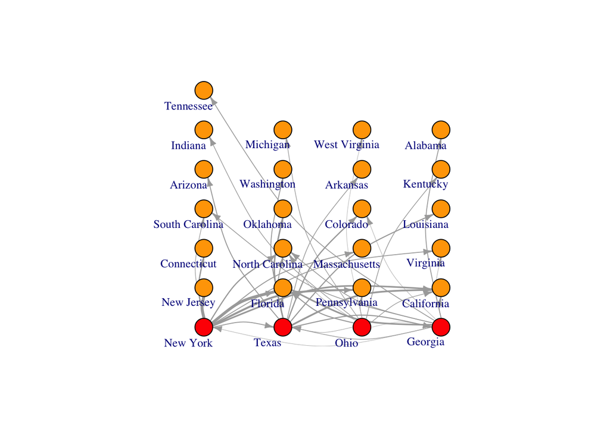

```r
plot(network, vertex.label.cex=0.8,
     vertex.label.dist=-2.5,
     layout = layout.grid(network, width = 4),
     edge.curved=0.26)
```

From the graph, people from New York migrated most in 2018.  
- The top 5 destinations for New York residents are New Jersey, Florida, Pennsylvania, California and Connecticut  
- The top 5 destinations for Texas residents are California, Oklahoma, Colorado, Florida and Louisiana  
- The top 5 destinations for Ohio residents are Florida, Kentucky, Indiana, California and Michigan  
- The top 5 destinations for Georgia residents are Florida, Alabama, Tennessee, North Carolina and South Carolina

We can find that people usually choose their adjacent states and the states with more travelling options and working opportunities. Florida and California are very popular. Georgia sets a typical example that people from the south prefer staying at the south area or moving to the places where they could keep the original lifestyle and enjoy similar environment.